# Practical Machine Learning - Project

Jason Taylor

7/31/2016

Background

Using devices such as Jawbone Up, Nike FuelBand, and Fitbit it is now possible to collect a large amount of data about personal activity relatively inexpensively. These type of devices are part of the quantified self movement – a group of enthusiasts who take measurements about themselves regularly to improve their health, to find patterns in their behavior, or because they are tech geeks. One thing that people regularly do is quantify how much of a particular activity they do, but they rarely quantify how well they do it. In this project, your goal will be to use data from accelerometers on the belt, forearm, arm, and dumbell of 6 participants. They were asked to perform barbell lifts correctly and incorrectly in 5 different ways. More information is available from the website here: http://groupware.les.inf.puc-rio.br/har (see the section on the Weight Lifting Exercise Dataset).

The training data for this project are available here: https://d396qusza40orc.cloudfront.net/predmachlearn/pml-training.csv

The test data are available here: https://d396qusza40orc.cloudfront.net/predmachlearn/pml-testing.csv

This paper will show the data processing methods and model building used to predict the class of the particpants.

# Environment Setup

```r
library(knitr)
library(caret)
library(caret)
library(rpart)
library(corrplot)
library(randomForest)
library(fields)
```

# Data Retrieval & Processing

```r
# Download the data
TrainUrl <- "http://d396qusza40orc.cloudfront.net/predmachlearn/pml-training.csv"
TestUrl  <- "http://d396qusza40orc.cloudfront.net/predmachlearn/pml-testing.csv"
training <- read.csv(url(TrainUrl))
testing  <- read.csv(url(TestUrl))

# Split data into Training and Test partitions
set.seed(999)
inTrain  <- createDataPartition(training$classe, p = 0.6, list = FALSE)
TrainSet <- training[inTrain, ]
TestSet  <- training[-inTrain, ]

# Split TrainSet into 3 equal datasets for cross validation
set.seed(999)
inTrainSetSub1 <- createDataPartition(TrainSet$classe, p = 0.33, list=FALSE)
TrainSetSub1 <- TrainSet[inTrainSetSub1,]
TrainSetRemainder <- TrainSet[-inTrainSetSub1,]
set.seed(999)
inTrainSetSub2 <- createDataPartition(TrainSetRemainder$classe, p=0.5, list=FALSE)
TrainSetSub2 <- TrainSetRemainder[inTrainSetSub2,]
TrainSetSub3 <- TrainSetRemainder[-inTrainSetSub2,]

# Divide each of these 3 sets into training (60%) and test (40%) sets.
set.seed(999)
inTrain <- createDataPartition(TrainSetSub1$classe, p=0.6, list=FALSE)
small_training1 <- TrainSetSub1[inTrain,]
small_testing1 <- TrainSetSub1[-inTrain,]
set.seed(999)
inTrain <- createDataPartition(TrainSetSub2$classe, p=0.6, list=FALSE)
small_training2 <- TrainSetSub2[inTrain,]
small_testing2 <- TrainSetSub2[-inTrain,]
set.seed(999)
inTrain <- createDataPartition(TrainSetSub3$classe, p=0.6, list=FALSE)
small_training3 <- TrainSetSub3[inTrain,]
small_testing3 <- TrainSetSub3[-inTrain,]

# Identification and removal of near zero variance predictors
nearZeroVariants <- nearZeroVar(TrainSet)
TrainSet <- TrainSet[, -nearZeroVariants]
small_training1 <- small_training1[, -nearZeroVariants]
small_training2 <- small_training2[, -nearZeroVariants]
small_training3 <- small_training3[, -nearZeroVariants]
TestSet  <- TestSet[, -nearZeroVariants]
small_testing1 <- small_testing1[, -nearZeroVariants]
small_testing2 <- small_testing2[, -nearZeroVariants]
small_testing3 <- small_testing3[, -nearZeroVariants]

# Identification and removal of NA valued predictors
colsMostlyNAs <- lapply( TrainSet, function(x) sum(is.na(x)) / length(x) ) < 0.1
TrainSet <- TrainSet[, colsMostlyNAs]
small_training1 <- small_training1[, colsMostlyNAs]
small_training2 <- small_training2[, colsMostlyNAs]
small_training3 <- small_training3[, colsMostlyNAs]
TestSet <- TestSet[, colsMostlyNAs]
small_testing1 <- small_testing1[, colsMostlyNAs]
small_testing2 <- small_testing2[, colsMostlyNAs]
small_testing3 <- small_testing3[, colsMostlyNAs]

# Remove variables used for identification(columns 1 to 5)
TrainSet <- TrainSet[, -(1:5)]
small_training1 <- small_training1[, -(1:5)]
small_training2 <- small_training2[, -(1:5)]
small_training3 <- small_training3[, -(1:5)]
TestSet  <- TestSet[, -(1:5)]
small_testing1  <- small_testing1[, -(1:5)]
small_testing2  <- small_testing2[, -(1:5)]
small_testing3  <- small_testing3[, -(1:5)]
```

# Model Building

Two models will be used and the one with the best average accuracy when applied to the cross validated training and test sets will be used to predict on the TestSet for the quiz question. A Confusion Matrix is plotted at the end of each analysis to better visualize the accuracy of the models.

# Method 1: Random Forest

```r
controlRF <- trainControl(method = "cv", number = 3, verboseIter = FALSE)
modFitRandForest <- train(classe ~ ., data = TrainSet, method = "rf", trControl = controlRF)
modFitRandForest1 <- train(classe ~ ., data = small_training1, method = "rf", trControl = controlRF)
modFitRandForest2 <- train(classe ~ ., data = small_training2, method = "rf", trControl = controlRF)
modFitRandForest3 <- train(classe ~ ., data = small_training3, method = "rf", trControl = controlRF)
modFitRandForest1$finalModel
```

```
##
## Call:
##  randomForest(x = x, y = y, mtry = param$mtry)
##                Type of random forest: classification
##                      Number of trees: 500
## No. of variables tried at each split: 53
##
##         OOB estimate of  error rate: 3.81%
## Confusion matrix:
##     A   B   C   D   E class.error
## A 661   1   0   0   1 0.003016591
## B  13 421  15   2   1 0.068584071
## C   1  15 384   7   0 0.056511057
## D   1   2  11 367   2 0.041775457
## E   1   7   1   8 412 0.039627040
```

```r
modFitRandForest2$finalModel
```

```
##
## Call:
##  randomForest(x = x, y = y, mtry = param$mtry)
##                Type of random forest: classification
##                      Number of trees: 500
## No. of variables tried at each split: 27
##
##         OOB estimate of  error rate: 3.71%
## Confusion matrix:
##     A   B   C   D   E class.error
## A 665   1   2   4   2  0.01335312
## B  18 430   9   1   0  0.06113537
## C   0  15 396   2   0  0.04116223
## D   1   2  15 368   3  0.05398458
## E   0   6   3   4 422  0.02988506
```

```r
modFitRandForest3$finalModel
```

```
##
## Call:
##  randomForest(x = x, y = y, mtry = param$mtry)
##                Type of random forest: classification
##                      Number of trees: 500
## No. of variables tried at each split: 27
##
##         OOB estimate of  error rate: 3.63%
## Confusion matrix:
##     A   B   C   D   E class.error
## A 672   0   0   1   0 0.001485884
## B  15 423  16   3   1 0.076419214
## C   0  11 399   3   0 0.033898305
## D   2   0  18 366   2 0.056701031
## E   0   2   5   7 421 0.032183908
```

```r
# Random Forest prediction on Test dataset
predictRandForest1 <- predict(modFitRandForest1, newdata = small_testing1)
predictRandForest2 <- predict(modFitRandForest2, newdata = small_testing2)
predictRandForest3 <- predict(modFitRandForest3, newdata = small_testing3)
confMatRandForest1 <- confusionMatrix(predictRandForest1, small_testing1$classe)
confMatRandForest2 <- confusionMatrix(predictRandForest2, small_testing2$classe)
confMatRandForest3 <- confusionMatrix(predictRandForest3, small_testing3$classe)
confMatRandForest1
```

```
## Confusion Matrix and Statistics
##
##           Reference
## Prediction   A   B   C   D   E
##          A 440  12   0   0   1
##          B   0 288   3   1   2
##          C   2   1 265   8   2
##          D   0   0   3 245   6
##          E   0   0   0   0 275
##
## Overall Statistics
##
##                Accuracy : 0.9736
##                  95% CI : (0.9644, 0.981)
##     No Information Rate : 0.2844
##     P-Value [Acc > NIR] : < 2.2e-16
##
##                   Kappa : 0.9666
##  Mcnemar's Test P-Value : NA
##
## Statistics by Class:
##
##                      Class: A Class: B Class: C Class: D Class: E
## Sensitivity            0.9955   0.9568   0.9779   0.9646   0.9615
## Specificity            0.9883   0.9952   0.9899   0.9931   1.0000
## Pos Pred Value         0.9713   0.9796   0.9532   0.9646   1.0000
## Neg Pred Value         0.9982   0.9897   0.9953   0.9931   0.9914
## Prevalence             0.2844   0.1937   0.1744   0.1634   0.1840
## Detection Rate         0.2831   0.1853   0.1705   0.1577   0.1770
## Detection Prevalence   0.2915   0.1892   0.1789   0.1634   0.1770
## Balanced Accuracy      0.9919   0.9760   0.9839   0.9788   0.9808
```

```r
confMatRandForest2
```

```
## Confusion Matrix and Statistics
##
##           Reference
## Prediction   A   B   C   D   E
##          A 448  11   0   0   0
##          B   0 290   4   1   1
##          C   0   4 267   4   2
##          D   0   0   4 253   5
##          E   0   0   0   0 282
##
## Overall Statistics
##
##                Accuracy : 0.9772
##                  95% CI : (0.9685, 0.984)
##     No Information Rate : 0.2843
##     P-Value [Acc > NIR] : < 2.2e-16
##
##                   Kappa : 0.9711
##  Mcnemar's Test P-Value : NA
##
## Statistics by Class:
##
##                      Class: A Class: B Class: C Class: D Class: E
## Sensitivity            1.0000   0.9508   0.9709   0.9806   0.9724
## Specificity            0.9902   0.9953   0.9923   0.9932   1.0000
## Pos Pred Value         0.9760   0.9797   0.9639   0.9656   1.0000
## Neg Pred Value         1.0000   0.9883   0.9938   0.9962   0.9938
## Prevalence             0.2843   0.1935   0.1745   0.1637   0.1840
## Detection Rate         0.2843   0.1840   0.1694   0.1605   0.1789
## Detection Prevalence   0.2912   0.1878   0.1758   0.1662   0.1789
## Balanced Accuracy      0.9951   0.9730   0.9816   0.9869   0.9862
```

```r
confMatRandForest3
```

```
## Confusion Matrix and Statistics
##
##           Reference
## Prediction   A   B   C   D   E
##          A 443   9   0   1   0
##          B   0 287   4   0   0
##          C   3   8 271   9   0
##          D   2   1   0 248   3
##          E   0   0   0   0 287
##
## Overall Statistics
##
##                Accuracy : 0.9746
##                  95% CI : (0.9656, 0.9818)
##     No Information Rate : 0.2843
##     P-Value [Acc > NIR] : < 2.2e-16
##
##                   Kappa : 0.9679
##  Mcnemar's Test P-Value : NA
##
## Statistics by Class:
##
##                      Class: A Class: B Class: C Class: D Class: E
## Sensitivity            0.9888   0.9410   0.9855   0.9612   0.9897
## Specificity            0.9911   0.9969   0.9846   0.9954   1.0000
## Pos Pred Value         0.9779   0.9863   0.9313   0.9764   1.0000
## Neg Pred Value         0.9955   0.9860   0.9969   0.9924   0.9977
## Prevalence             0.2843   0.1935   0.1745   0.1637   0.1840
## Detection Rate         0.2811   0.1821   0.1720   0.1574   0.1821
## Detection Prevalence   0.2874   0.1846   0.1846   0.1612   0.1821
## Balanced Accuracy      0.9900   0.9689   0.9850   0.9783   0.9948
```

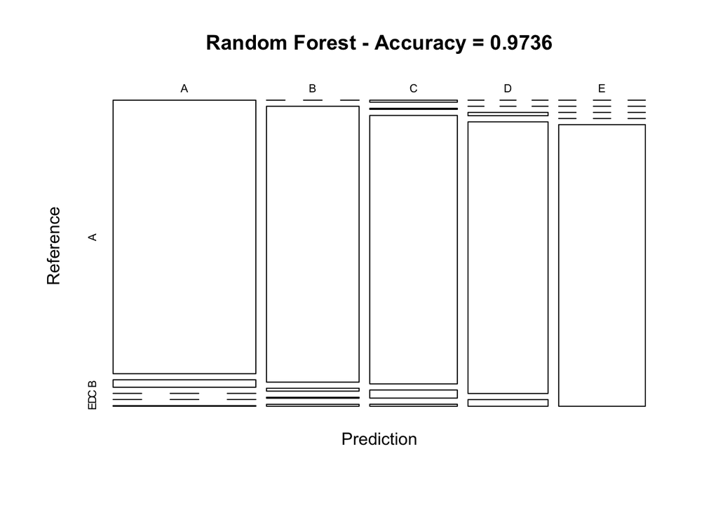

```r
# Plot Random Forest resulting confusion matrix for modFitRandForest1, not plotting all to save space.
plot(confMatRandForest1$table, col = confMatRandForest1$byClass, main = paste("Random Forest - Accuracy =", round(confMatRandForest1$overall['Accuracy'], 4)))
```

```r
# Accuracy modFitRandForest1: = 97.36%, OOB estimate of  error rate: 3.81%
# Accuracy modFitRandForest2: = 97.72%, OOB estimate of  error rate: 3.71%
# Accuracy modFitRandForest3: = 97.46%, OOB estimate of  error rate: 3.63%
```